# Parking in Copenhagen

The municipality of Copenhagen has released a dataset of historical parking transactions in the city of Copenhagen between 2010 and 2014. The dataset contain nearly 44 million transactions, each of which describe the date and time of the purchase of the parking ticket as well as the date and time of the expiration of the ticket.  
The full dataset can be found at [the open data homepage of the nunicipality of Copenhagen](http://www.data.kk.dk)  
In this notebook, I use python and pandas to explore and find patterns in the data.  
My initial hypothesis:  
Drivers in Copenhagen have bought parking tickets that significantly exceed their actual parking needs.

# Merging the data

The data is distributed over multiple files. I have merged the sets using:

"""  
import glob  
files = glob.glob('parkomat*.csv') fout = open('park_all_old.csv','a')  
#copying first file with headers into the merged csv  
first_file = files[0]  
for line in open(first_file):  
fout.write(line)  
#copying the remaining files:  
for remaining_files in glob.glob('parkomat*.csv')[1:]:  
f = open(remaining_files)  
next(f) #sskipping first line ie header  
for line in f:  
fout.write(line)  
f.close()  
fout.close()  
"""

# Importing and cleaning the data

First I'll import the usual suspects:

```python
import pandas as pd
import numpy as np
import matplotlib.pyplot as plt
import seaborn as sns
import datetime as dt
%pylab inline
```

```python
park_all = pd.read_csv('park_all_old.csv')
park_all.head(3)
```

|  | tlRecordID | tlPDM | tlPayDateTime | tlExpDateTime |
| --- | --- | --- | --- | --- |
| 0 | 64085063 | 8064 | 2014-02-11 17:31:00 | 2014-02-11 19:04:00 |
| 1 | 64085064 | 3965 | 2014-02-11 17:31:00 | 2014-02-11 18:41:00 |
| 2 | 64085065 | 8107 | 2014-02-11 17:31:00 | 2014-02-11 20:09:00 |

as seen, each row in the data represents a parking transaction and contains information about vendor number, date and time of the payment and expiration time of the ticket. Let us see whether the timestamps have been imported correctly:

```python
park_all.dtypes
```

[output not shown]

```python
park_all = pd.read_csv('park_all_old.csv', parse_dates = ['tlPayDateTime', 'tlExpDateTime'])
```

```python
park_all.dtypes
```

```
tlRecordID                int64
tlPDM                     int64
tlPayDateTime    datetime64[ns]
tlExpDateTime    datetime64[ns]
dtype: object
```

That's better and we can now do operations with the timestamps.  
The starting and end times of each parking transaction in themselves are not of major interest. However, the timedelta between the two is. I'll calculate that

```python
park_all['diff'] = park_all['tlExpDateTime'] - park_all['tlPayDateTime']
```

We can now start to look at some simple descriptive statistics

```python
park_all.describe()
```

|  | tlRecordID | tlPDM | diff |
| --- | --- | --- | --- |
| count | 4.399805e+07 | 4.399805e+07 | 43882204 |
| mean | 4.890198e+07 | 3.792598e+03 | 0 days 04:06:08.690834 |
| std | 1.307654e+07 | 2.693205e+03 | 30 days 12:42:10.467522 |
| min | 2.606871e+07 | 1.000000e+00 | -41944 days +08:53:00 |
| 25% | 3.749359e+07 | 2.364000e+03 | 0 days 00:55:00 |
| 50% | 4.911633e+07 | 3.593000e+03 | 0 days 01:49:00 |
| 75% | 6.020127e+07 | 4.256000e+03 | 0 days 03:37:00 |
| max | 7.175215e+07 | 6.969900e+04 | 11682 days 23:15:00 |

Some initial observations:

- In the period 2010-2014, almost 44 million parking transactions has veen made. That's a lot
- The data contains some nonsense values. Parking your car for a negative number of hours, and for more than 30 years does not make sense. We need to take that into account when looking at the data

## Selecting data

I'll use boolean indexing to select only relevant data. Parking for a negative number of hours does not make sense,. I will thus set 0 as the lower bound.  
The majority of payments are made for parking below 5 hours. I will thus set 5 as the upper bound.

```python
park_all = park_all[park_all['diff'] > pd.Timedelta(0)]
park_all = park_all[park_all['diff'] < pd.Timedelta(hours=5)]
```

```python
park_all.describe()
```

|  | tlRecordID | tlPDM | diff |
| --- | --- | --- | --- |
| count | 3.603487e+07 | 3.603487e+07 | 36034870 |
| mean | 4.877726e+07 | 3.786885e+03 | 0 days 01:42:42.029436 |
| std | 1.306712e+07 | 2.409684e+03 | 0 days 01:08:34.938289 |
| min | 2.606923e+07 | 1.520000e+02 | 0 days 00:01:00 |
| 25% | 3.736317e+07 | 2.365000e+03 | 0 days 00:53:00 |
| 50% | 4.892094e+07 | 3.595000e+03 | 0 days 01:27:00 |
| 75% | 6.004888e+07 | 4.268000e+03 | 0 days 02:19:00 |
| max | 7.155628e+07 | 6.969600e+04 | 0 days 04:59:00 |

The data has been cleaned up, and we can now start answering some questions

# Do the parking payment correspond to the actual parking need?

We already know that the average parking ticket expires after 1 hour and 42 minutes. But this statistic does not say much about how the data is distributed. Let's look at the data in a histogram.  
'To be able to plot the time differences in a historgram, we need to convert it to floats. I do that by dividing by a timedelta of 1 hour. This will give us time differences in hours.

```python
park_all['diff'] = (park_all['diff'] / pd.Timedelta(hours=1))
```

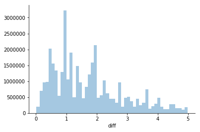

```python
sns.distplot(park_all['diff'], bins=50, kde=False)
sns.despine()
```

The histogram reveals some interesting patterns: